# IODS course project

## 2. Principal component analysis (PCA)

```r
# PCA
human_pca <- prcomp(human_)
# Summary of the PCA
human_pca_s <- summary(human_pca)
# Rounded percentages of variance
human_pca_pr <- round(1*human_pca_s$importance[2, ], digits = 5)
# Print out the rounded summary percentages
human_pca_pr
```

```
##    PC1    PC2    PC3    PC4    PC5    PC6    PC7    PC8
## 0.9999 0.0001 0.0000 0.0000 0.0000 0.0000 0.0000 0.0000
```

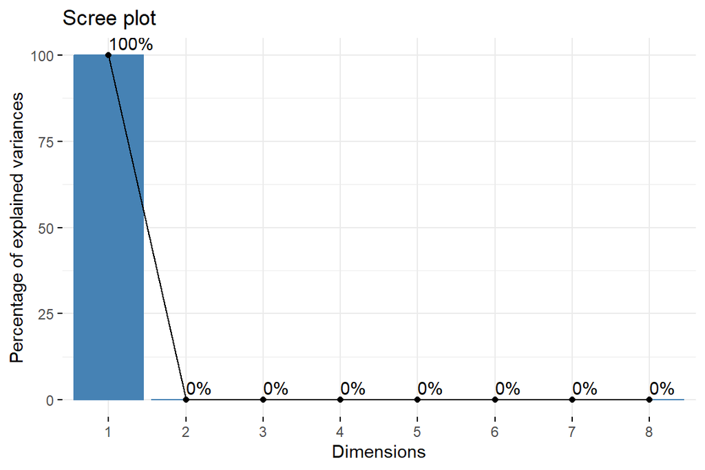

```r
# Library for graph regarding the variability
library(factoextra)
fviz_eig(human_pca, addlabels = TRUE)
```

As seen here $99\%$ of the variability is explained by principal component 1. This makes the analysis rather boring and as seen in the following biplot the values cramp up on the upper right corner. This makes difficult to see differences, hence the standardization in the next subsection.

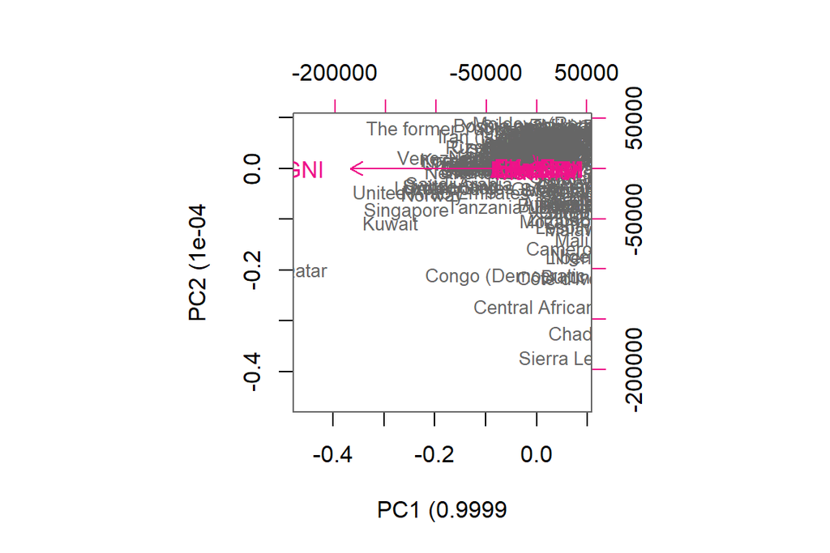

```r
# Axis lables
pc_lab <- paste0(names(human_pca_pr), " (", human_pca_pr)

# Biplot of the PCA representation and the original values
# Axis labels from pc_lab
biplot(human_pca, cex = c(0.8, 1), col = c("grey40", "deeppink2"), xlab = pc_lab[1], ylab = pc_lab[2])
```

As can be seen in the biplot up there, it’s quite difficult to make any differences from it. This was anticipated as the PC1 contributes $99\%$ of the variability.

With biplot, it is possible to visualize the similarities and dissimilarities between the samples, and it further shows the impact of each attribute on each of the principal components.

Some biplot properties:

- Variables grouped together are positively correlated to each other.
- Higher the distance between the variable and the origin, the better represented the variable is.
- Variables that are negatively correlated are displayed to the opposite sides of the biplot’s origin.

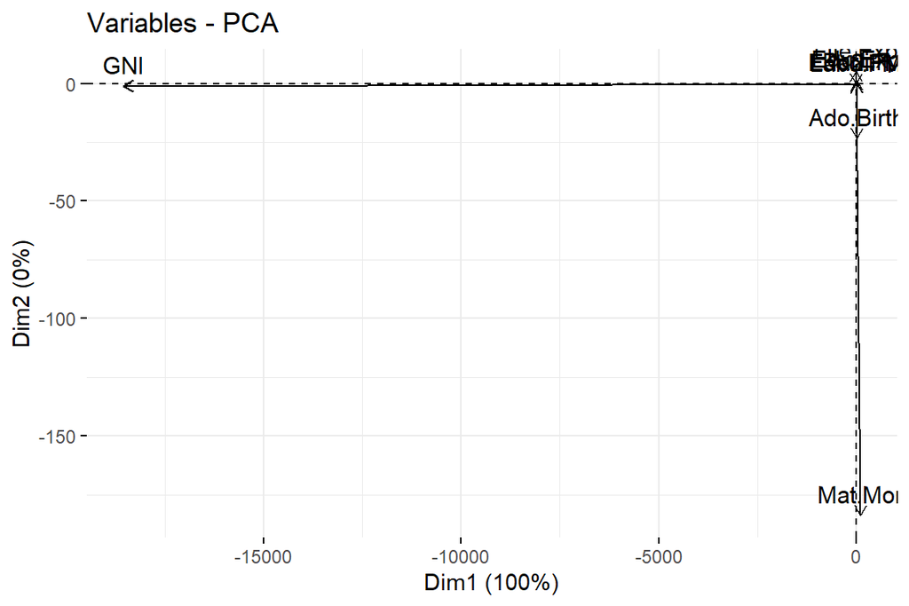

```r
# An another type of graph
fviz_pca_var(human_pca)
```

Well, this did not work too well. Let’s see how does it work with standardized data.

## 3. Standardized variables PCA

```r
# Standardizing the variables
human_std <- scale(human_)

# PCA
human_std_pca <- prcomp(human_std)
# Summary of the PCA
human_std_pca_s <- summary(human_std_pca)
# Rounded percentages of variance
human_std_pca_pr <- round(1*human_std_pca_s$importance[2, ], digits = 5)
# Print out the rounded summary percentages
human_std_pca_pr
```

```
##     PC1     PC2     PC3     PC4     PC5     PC6     PC7     PC8
## 0.53605 0.16237 0.09571 0.07583 0.05477 0.03595 0.02634 0.01298
```

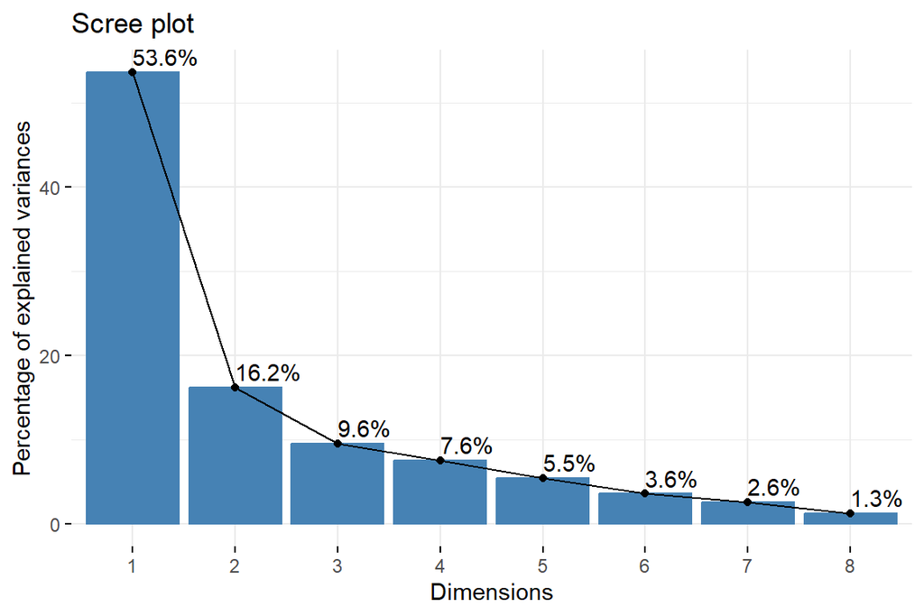

```r
# Graph about the same data = Scree plot
fviz_eig(human_std_pca, addlabels = TRUE)
```

Here the different principal components are more “evenly” distributed. Principal component 1 accounts $53.6\%$ of variability and principal component 2 $16.2\%$ of variability. Together PC1 and PC2 constitute of $69.8\%$ of variablity.

The standardized values are important within the principal component analysis as the original predictors may have different scales (as they do in this dataset). The un-normalized data will lead to the dependence of a principal component (as seen earlier) .

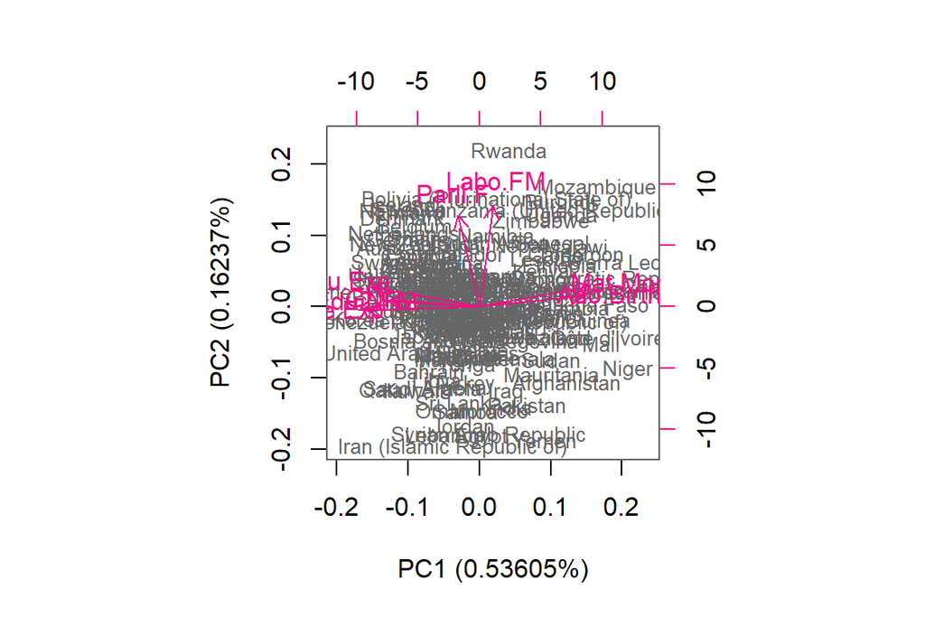

```r
# Axis labels
pc_lab_std <- paste0(names(human_std_pca_pr), " (", human_std_pca_pr, "%)")

# Biplot of the PCA representation of the standardized values and the original values
# Axis labels from pc_lab_std
biplot(human_std_pca, cex = c(0.8, 1), col = c("grey40", "deeppink2"), xlab = pc_lab_std[1], ylab = pc_lab_std[2])
```

Again, the graphs show that Maternal Mortality and Adolescent Birth Rate correlate positively with each other and negatively with Education Expectancy, Life Expectancy and GNI. Education Expectancy, Life Expectancy and GNI correlate positively with each other.

It can be seen that the Maternal Mortality and Adolescent Birth Rate have higher values within African nations, e.g., Sierra Leon and Burkina Faso, whereas the higher life and education expensiveness concentrate on more with Western highly industrialized nations. The countries from the Middle-east are on the bottom which signifies that there the workforce constitutes of men much more than women.

Let’s combine Cos2 analysis with biplot.

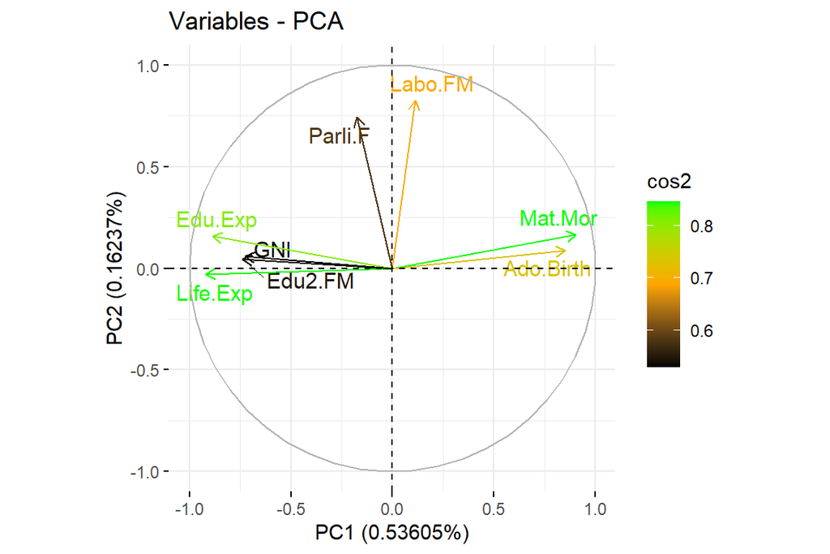

```r
# An another type of graph = correlation circle + Cos2 values

fviz_pca_var(human_std_pca, col.var = "cos2",
            gradient.cols = c("black", "orange", "green"),
            repel = TRUE, xlab = pc_lab_std[1], ylab = pc_lab_std[2])
```

The upper graph visualizes (with Cos2 values) how much each variable is represented in a given component. A low value mean that the variable is not perfectly represented by that component and a high value means a good representation of the variable on that component (PC1 and PC2 in this case). It is combined with biplot described earlier.

- High cos2 attributes are colored in green: Maternal Mortality, Life Expectancy, and Education Expectancy
- Mid cos2 attributes have an orange color: Adolescent Birth Rate and Labour Force Participation Rate female / male ratio
- Low cos2 attributes have a black color: Percent Representation in Parliament (Female), GNI, and Education Expectancy female / male ratio

The variables having the high cos2 values represent the variables that are having good representation within the principal components (1&2).

## 4. Interpretation of the first two principal components

Variables that have mostly to do with **PC1** variance

- Maternal Mortality
- Life Expectancy
- Education Expectancy
- Adolescent Birth Rate

Variables that have mostly to do with **PC2** variance

- Labour Force Participation Rate female / male ratio
- Percent Representation in Parliament (Female)

It would seem that the principal component analysis digs out two types of groups of variables that are important: group 1 has to do with maybe more individual level (life and health of individuals) and group 2 has to do with more societal impacts (labor market and politics).

Countries divide here into four quadrants

## 5. Tea data, MCA

### Data loading and description

```r
# Load data
tea <- read.csv("https://raw.githubusercontent.com/KimmoVehkalahti/Helsinki-Open-Data-Science/master/datasets/tea.csv", stringsAsFactors = TRUE)
# Load libraries
library(tidyr)

# ---- Smaller dataset with just couple of columns (factorial variables)

# column names to keep in the dataset

keep_columns <- c("Tea", "How", "how", "sugar", "where", "lunch")

# select the 'keep_columns' to create a new dataset
suppressWarnings({
tea_time <- dplyr::select(tea, keep_columns)})

# look at the summaries and structure of the data tea dataset
names(tea)
```

```
##  [1] "breakfast"        "tea.time"         "evening"          "lunch"
##  [5] "dinner"           "always"           "home"             "work"
##  [9] "tearoom"          "friends"          "resto"            "pub"
## [13] "Tea"              "How"              "sugar"            "how"
## [17] "where"            "price"            "age"              "sex"
## [21] "SPC"              "Sport"            "age_Q"            "frequency"
## [25] "escape.exoticism" "spirituality"     "healthy"          "diuretic"
## [29] "friendliness"     "iron.absorption"  "feminine"         "sophisticated"
## [33] "slimming"         "exciting"         "relaxing"         "effect.on.health"
```

```r
head(tea) # 6 first rows
```

```
##       breakfast     tea.time     evening     lunch     dinner     always home
## 1     breakfast Not.tea time Not.evening Not.lunch Not.dinner Not.always home
## 2     breakfast Not.tea time Not.evening Not.lunch Not.dinner Not.always home
## 3 Not.breakfast     tea time     evening Not.lunch     dinner Not.always home
## 4 Not.breakfast Not.tea time Not.evening Not.lunch     dinner Not.always home
## 5     breakfast Not.tea time     evening Not.lunch Not.dinner     always home
## 6 Not.breakfast Not.tea time Not.evening Not.lunch     dinner Not.always home
##       work     tearoom     friends     resto     pub       Tea   How    sugar
## 1 Not.work Not.tearoom Not.friends Not.resto Not.pub     black alone    sugar
## 2 Not.work Not.tearoom Not.friends Not.resto Not.pub     black  milk No.sugar
## 3     work Not.tearoom     friends     resto Not.pub Earl Grey alone No.sugar
## 4 Not.work Not.tearoom Not.friends Not.resto Not.pub Earl Grey alone    sugar
## 5 Not.work Not.tearoom Not.friends Not.resto Not.pub Earl Grey alone No.sugar
## 6 Not.work Not.tearoom Not.friends Not.resto Not.pub Earl Grey alone No.sugar
##       how       where           price age sex          SPC         Sport age_Q
```

[output cut: 27 more lines]

Variables and their possible values within tea dataset

```r
str(tea) # Variables, factors and their possible values
```

```
## 'data.frame':    300 obs. of  36 variables:
##  $ breakfast       : Factor w/ 2 levels "breakfast","Not.breakfast": 1 1 2 2 1 2 1 2 1 1 ...
##  $ tea.time        : Factor w/ 2 levels "Not.tea time",..: 1 1 2 1 1 1 2 2 2 1 ...
##  $ evening         : Factor w/ 2 levels "evening","Not.evening": 2 2 1 2 1 2 2 1 2 1 ...
##  $ lunch           : Factor w/ 2 levels "lunch","Not.lunch": 2 2 2 2 2 2 2 2 2 2 ...
##  $ dinner          : Factor w/ 2 levels "dinner","Not.dinner": 2 2 1 1 2 1 2 2 2 2 ...
##  $ always          : Factor w/ 2 levels "always","Not.always": 2 2 2 2 1 2 2 2 2 2 ...
##  $ home            : Factor w/ 2 levels "home","Not.home": 1 1 1 1 1 1 1 1 1 1 ...
##  $ work            : Factor w/ 2 levels "Not.work","work": 1 1 2 1 1 1 1 1 1 1 ...
##  $ tearoom         : Factor w/ 2 levels "Not.tearoom",..: 1 1 1 1 1 1 1 1 1 2 ...
##  $ friends         : Factor w/ 2 levels "friends","Not.friends": 2 2 1 2 2 2 1 2 2 2 ...
##  $ resto           : Factor w/ 2 levels "Not.resto","resto": 1 1 2 1 1 1 1 1 1 1 ...
##  $ pub             : Factor w/ 2 levels "Not.pub","pub": 1 1 1 1 1 1 1 1 1 1 ...
##  $ Tea             : Factor w/ 3 levels "black","Earl Grey",..: 1 1 2 2 2 2 2 1 2 1 ...
##  $ How             : Factor w/ 4 levels "alone","lemon",..: 1 3 1 1 1 1 1 3 3 1 ...
```

[output cut: 22 more lines]

```r
dim(tea) #Dimensions 300x36
```

```
## [1] 300  36
```

Variables and their possible values within tea_time (reduced) dataset

```r
str(tea_time) # Variables, factors and their possible values
```

```
## 'data.frame':    300 obs. of  6 variables:
##  $ Tea  : Factor w/ 3 levels "black","Earl Grey",..: 1 1 2 2 2 2 2 1 2 1 ...
##  $ How  : Factor w/ 4 levels "alone","lemon",..: 1 3 1 1 1 1 1 3 3 1 ...
##  $ how  : Factor w/ 3 levels "tea bag","tea bag+unpackaged",..: 1 1 1 1 1 1 1 1 2 2 ...
##  $ sugar: Factor w/ 2 levels "No.sugar","sugar": 2 1 1 2 1 1 1 1 1 1 ...
##  $ where: Factor w/ 3 levels "chain store",..: 1 1 1 1 1 1 1 1 2 2 ...
##  $ lunch: Factor w/ 2 levels "lunch","Not.lunch": 2 2 2 2 2 2 2 2 2 2 ...
```

```r
dim(tea_time) #Dimensions 300x6
```

```
## [1] 300   6
```

### Multiple Correspondence Analysis

```r
# Even more libraries
suppressWarnings({
library(FactoMineR) })

# Well, clearly something is not working with all of the columns, different data types?
#mca <- MCA(tea, graph = FALSE)

# MCA with smaller number of columns
mca_time <- MCA(tea_time, graph = FALSE)

# summary of the model
summary(mca_time)
```

```
##
## Call:
## MCA(X = tea_time, graph = FALSE)
##
##
## Eigenvalues
##                        Dim.1   Dim.2   Dim.3   Dim.4   Dim.5   Dim.6   Dim.7
## Variance               0.279   0.261   0.219   0.189   0.177   0.156   0.144
## % of var.             15.238  14.232  11.964  10.333   9.667   8.519   7.841
## Cumulative % of var.  15.238  29.471  41.435  51.768  61.434  69.953  77.794
##                        Dim.8   Dim.9  Dim.10  Dim.11
## Variance               0.141   0.117   0.087   0.062
## % of var.              7.705   6.392   4.724   3.385
## Cumulative % of var.  85.500  91.891  96.615 100.000
##
## Individuals (the 10 first)
##                       Dim.1    ctr   cos2    Dim.2    ctr   cos2    Dim.3
## 1                  | -0.298  0.106  0.086 | -0.328  0.137  0.105 | -0.327
## 2                  | -0.237  0.067  0.036 | -0.136  0.024  0.012 | -0.695
## 3                  | -0.369  0.162  0.231 | -0.300  0.115  0.153 | -0.202
## 4                  | -0.530  0.335  0.460 | -0.318  0.129  0.166 |  0.211
## 5                  | -0.369  0.162  0.231 | -0.300  0.115  0.153 | -0.202
## 6                  | -0.369  0.162  0.231 | -0.300  0.115  0.153 | -0.202
## 7                  | -0.369  0.162  0.231 | -0.300  0.115  0.153 | -0.202
## 8                  | -0.237  0.067  0.036 | -0.136  0.024  0.012 | -0.695
## 9                  |  0.143  0.024  0.012 |  0.871  0.969  0.435 | -0.067
## 10                 |  0.476  0.271  0.140 |  0.687  0.604  0.291 | -0.650
##                       ctr   cos2
## 1                   0.163  0.104 |
## 2                   0.735  0.314 |
## 3                   0.062  0.069 |
## 4                   0.068  0.073 |
## 5                   0.062  0.069 |
## 6                   0.062  0.069 |
## 7                   0.062  0.069 |
## 8                   0.735  0.314 |
## 9                   0.007  0.003 |
## 10                  0.643  0.261 |
##
## Categories (the 10 first)
```

[output cut: 16 more lines]

```
## lemon                3.226 |   1.329  14.771   0.218   8.081 |
## milk                 2.422 |   0.013   0.003   0.000   0.116 |
## other                5.534 |  -2.524  14.526   0.197  -7.676 |
## tea bag             -6.941 |  -0.065   0.183   0.006  -1.287 |
## tea bag+unpackaged  11.956 |   0.019   0.009   0.000   0.226 |
## unpackaged          -6.482 |   0.257   0.602   0.009   1.640 |
##
## Categorical variables (eta2)
##                      Dim.1 Dim.2 Dim.3
## Tea                | 0.126 0.108 0.410 |
## How                | 0.076 0.190 0.394 |
## how                | 0.708 0.522 0.010 |
## sugar              | 0.065 0.001 0.336 |
## where              | 0.702 0.681 0.055 |
## lunch              | 0.000 0.064 0.111 |
```

The summary states that the Dimensions 1 & 2 have $15.238\%$ and $14.232\%$ of variance respectively. Altogether there are 11 dimensions.

Plotting the results of tea_time (reduced) dataset

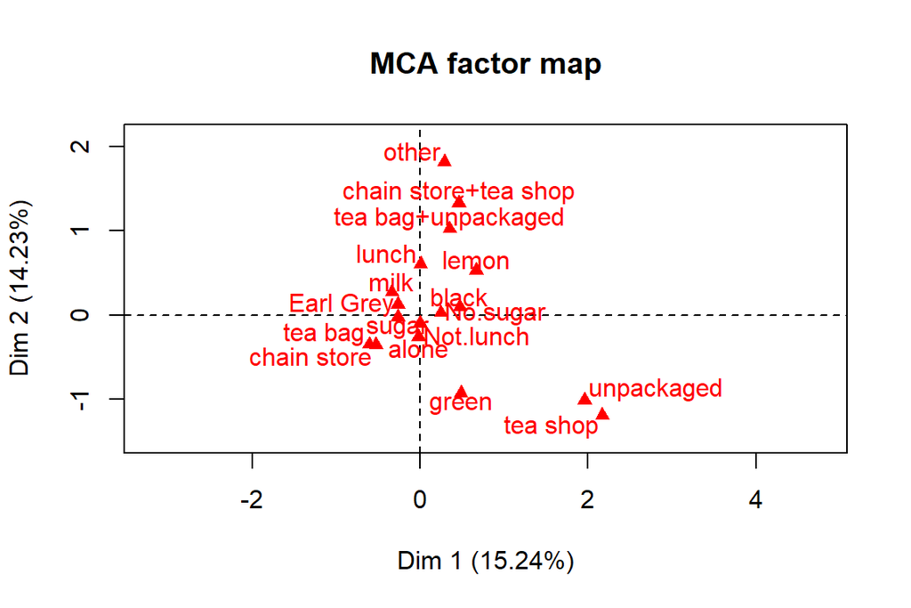

```r
# Plotting the results, biplot
plot(mca_time, invisible=c("ind"), graph.type = "classic")
```

Horizontal axis (Dimension 1) has to do with more refined (some might say elitist) way of drinking tea when going towards right (left: chain store / tea bags - right: tea shop / unpackaged).

Vertical axis (Dimension 2) has to do with perhaps in which kind of place the tea is consumed: store type, lunch or not. I’m not really sure about this.

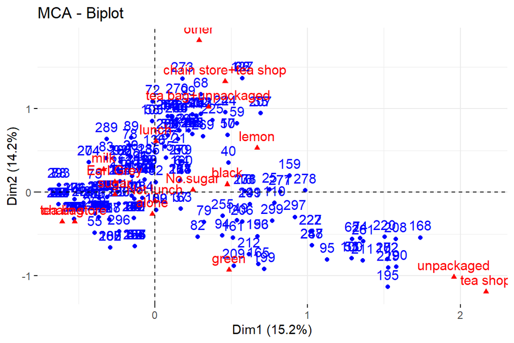

```r
fviz_mca_biplot(mca_time, repel = FALSE, ggtheme = theme_minimal())
```

Seems that 300 observations are too many for this representation. Some groupings can be seen:

- Unpackaged, tea shop, green tea “party”; low right. These guys vary the most.
- Tea shop+ chain store, lemon, black, lunch or not => anything goes; high center-right
- Earl Grey, milk, sugar, tea bag, chain store people; center left

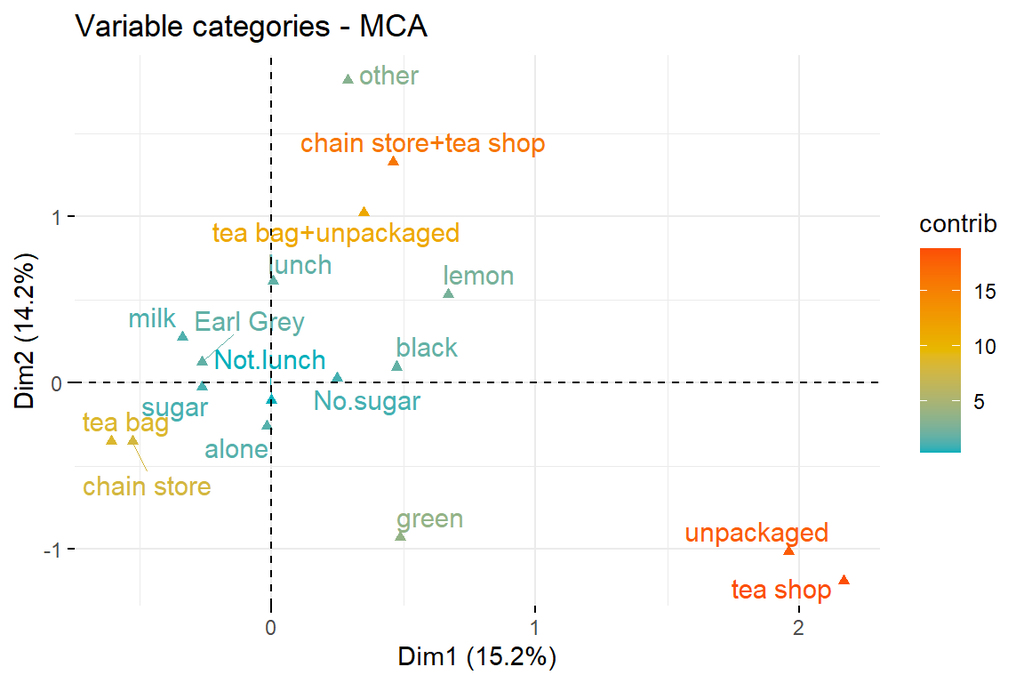

```r
fviz_mca_var(mca_time, col.var = "contrib", gradient.cols = c("#00AFBB", "#E7B800", "#FC4E07"), repel = TRUE, ggtheme = theme_minimal())
```

Here’s another iteration of MCA plots. This plot gives some idea of what poles of the dimensions the categories are actually contributing to.

Some observations:

- Categories unpacked and tea shop have an important contribution to the positive pole of the first dimension
- Combined category chain store+tea shop has an important contribution to the positive pole of the second dimension

# Chapter 6, Analysis Assignment 6

Although I have been working with longitudinal data a lot, I had bunch of troubles with this assignment. I guess they were mainly technical. Thus, the second part with BPRS data is not finished (plots not done as well as I wanted and not much interpretation) and there might be some things missing from the first part as well.

```r
date()
```

```
## [1] "Tue Dec 12 11:45:22 2023"
```

```r
# Load libraries
suppressWarnings({
library(tidyverse)
library(readr)
library(finalfit)
library(dplyr)
library(MASS)
library(corrplot)
library(GGally)
library(ggplot2)})
```

## Load and arrange data using meet_and_repeat.r

```r
# Load and arrange data using the earlier r code
source("meet_and_repeat.r")
```

```
## spc_tbl_ [40 × 11] (S3: spec_tbl_df/tbl_df/tbl/data.frame)
##  $ treatment: num [1:40] 1 1 1 1 1 1 1 1 1 1 ...
##  $ subject  : num [1:40] 1 2 3 4 5 6 7 8 9 10 ...
##  $ week0    : num [1:40] 42 58 54 55 72 48 71 30 41 57 ...
##  $ week1    : num [1:40] 36 68 55 77 75 43 61 36 43 51 ...
##  $ week2    : num [1:40] 36 61 41 49 72 41 47 38 39 51 ...
##  $ week3    : num [1:40] 43 55 38 54 65 38 30 38 35 55 ...
##  $ week4    : num [1:40] 41 43 43 56 50 36 27 31 28 53 ...
##  $ week5    : num [1:40] 40 34 28 50 39 29 40 26 22 43 ...
##  $ week6    : num [1:40] 38 28 29 47 32 33 30 26 20 43 ...
##  $ week7    : num [1:40] 47 28 25 42 38 27 31 25 23 39 ...
##  $ week8    : num [1:40] 51 28 24 46 32 25 31 24 21 32 ...
##  - attr(*, "spec")=
##   .. cols(
##   ..   treatment = col_double(),
##   ..   subject = col_double(),
##   ..   week0 = col_double(),
##   ..   week1 = col_double(),
##   ..   week2 = col_double(),
##   ..   week3 = col_double(),
##   ..   week4 = col_double(),
##   ..   week5 = col_double(),
##   ..   week6 = col_double(),
##   ..   week7 = col_double(),
##   ..   week8 = col_double()
##   .. )
##  - attr(*, "problems")=<externalptr>
```

```
## Rows: 16
## Columns: 13
## $ ID    <dbl> 1, 2, 3, 4, 5, 6, 7, 8, 9, 10, 11, 12, 13, 14, 15, 16
## $ Group <dbl> 1, 1, 1, 1, 1, 1, 1, 1, 2, 2, 2, 2, 3, 3, 3, 3
## $ WD1   <dbl> 240, 225, 245, 260, 255, 260, 275, 245, 410, 405, 445, 555, 470,…
## $ WD8   <dbl> 250, 230, 250, 255, 260, 265, 275, 255, 415, 420, 445, 560, 465,…
## $ WD15  <dbl> 255, 230, 250, 255, 255, 270, 260, 260, 425, 430, 450, 565, 475,…
## $ WD22  <dbl> 260, 232, 255, 265, 270, 275, 270, 268, 428, 440, 452, 580, 485,…
## $ WD29  <dbl> 262, 240, 262, 265, 270, 275, 273, 270, 438, 448, 455, 590, 487,…
## $ WD36  <dbl> 258, 240, 265, 268, 273, 277, 274, 265, 443, 460, 455, 597, 493,…
## $ WD43  <dbl> 266, 243, 267, 270, 274, 278, 276, 265, 442, 458, 451, 595, 493,…
## $ WD44  <dbl> 266, 244, 267, 272, 273, 278, 271, 267, 446, 464, 450, 595, 504,…
## $ WD50  <dbl> 265, 238, 264, 274, 276, 284, 282, 273, 456, 475, 462, 612, 507,…
## $ WD57  <dbl> 272, 247, 268, 273, 278, 279, 281, 274, 468, 484, 466, 618, 518,…
## $ WD64  <dbl> 278, 245, 269, 275, 280, 281, 284, 278, 478, 496, 472, 628, 525,…
```

[output cut: 46 more lines]

## 1. RATS data

```r
# Check the names and data types in dataframe rats_long
names(rats_long)
```

```
## [1] "ID"    "Group" "time"  "rats"
```

```r
str(rats_long) # appropriate variables still as factors
```

```
## tibble [176 × 4] (S3: tbl_df/tbl/data.frame)
##  $ ID   : Factor w/ 16 levels "1","2","3","4",..: 1 2 3 4 5 6 7 8 9 10 ...
##  $ Group: Factor w/ 3 levels "1","2","3": 1 1 1 1 1 1 1 1 2 2 ...
##  $ time : int [1:176] 1 1 1 1 1 1 1 1 1 1 ...
##  $ rats : num [1:176] 240 225 245 260 255 260 275 245 410 405 ...
```

### Plots

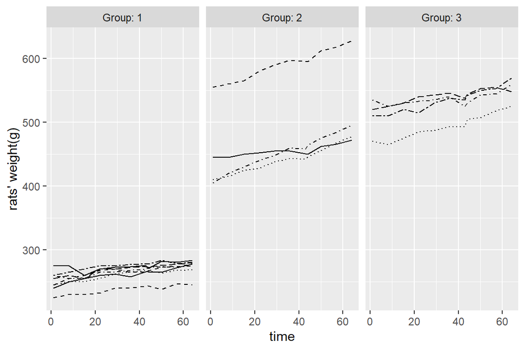

```r
# Time on x-axis and rats on y-axis rats body weight
ggplot(rats_long, aes(x= time, y = rats, linetype = ID)) + geom_line() + scale_linetype_manual(values = rep(1:10, times=4)) +
  facet_grid(. ~ Group, labeller = label_both) +
  theme(legend.position = "none") +
  scale_y_continuous(limits = c(min(rats_long$rats), max(rats_long$rats)), name = "rats' weight(g)")
```

Observations

- Group 1 has the lowest weights in the beginning and in the end of observation period. Slight upwards trend in weights. One clearly lighter rat.
- Group 2 is mainly in the middle in weights, however, there’s one rat that dwarfs all others in this data. Upwards trend showing as well.
- Group 3 has the heaviest rats in general. Again upwards trend seen.

```r
# Grouping by time and standardization of rats (weight)

rats_long <- rats_long %>% group_by(time) %>% mutate(stdrats = scale(rats)) %>% ungroup()
rats_long <- rats_long %>% group_by(Group, time) %>% mutate(stdrats_G = scale(rats)) %>% ungroup()
names(rats_long)
```

```
## [1] "ID"        "Group"     "time"      "rats"      "stdrats"   "stdrats_G"
```

```r
summary(rats_long) # stdrats mean 0
```

```
##        ID      Group       time            rats            stdrats.V1
##  1      : 11   1:88   Min.   : 1.00   Min.   :225.0   Min.   :-1.1617911
##  2      : 11   2:44   1st Qu.:15.00   1st Qu.:267.0   1st Qu.:-0.9083890
##  3      : 11   3:44   Median :36.00   Median :344.5   Median :-0.2061907
##  4      : 11          Mean   :33.55   Mean   :384.5   Mean   : 0.0000000
##  5      : 11          3rd Qu.:50.00   3rd Qu.:511.2   3rd Qu.: 0.9234591
##  6      : 11          Max.   :64.00   Max.   :628.0   Max.   : 1.6329587
##  (Other):110
##      stdrats_G.V1
##  Min.   :-2.3108535
##  1st Qu.:-0.4903813
##  Median : 0.0544619
##  Mean   : 0.0000000
##  3rd Qu.: 0.6161605
##  Max.   : 1.6013452
##
```

```r
ff_glimpse((rats_long)) # stdrats sd 1.0 as should be
```

```
## $Continuous
##               label  var_type   n missing_n missing_percent  mean    sd   min
## time           time     <int> 176         0             0.0  33.5  19.5   1.0
## rats           rats     <dbl> 176         0             0.0 384.5 127.2 225.0
## stdrats     stdrats <dbl[,1]> 176         0             0.0   0.0   1.0  -1.2
## stdrats_G stdrats_G <dbl[,1]> 176         0             0.0   0.0   0.9  -2.3
##           quartile_25 median quartile_75   max
## time             15.0   36.0        50.0  64.0
## rats            267.0  344.5       511.2 628.0
## stdrats          -0.9   -0.2         0.9   1.6
## stdrats_G        -0.5    0.1         0.6   1.6
##
## $Categorical
##       label var_type   n missing_n missing_percent levels_n        levels
## ID       ID    <fct> 176         0             0.0       16             -
## Group Group    <fct> 176         0             0.0        3 "1", "2", "3"
##       levels_count levels_percent
## ID               -              -
## Group   88, 44, 44     50, 25, 25
```

### Standardized plot

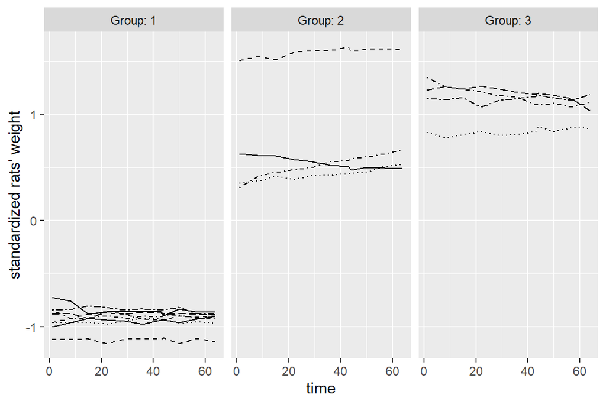

```r
# Time on x-axis and rats on y-axis rats body weight standardized
ggplot(rats_long, aes(x= time, y = stdrats, linetype = ID)) + geom_line() + scale_linetype_manual(values = rep(1:10, times=4)) +
  facet_grid(. ~ Group, labeller = label_both) +
  theme(legend.position = "none") +
  scale_y_continuous(name = "standardized rats' weight")
```

### Standardized (inside groups) plot

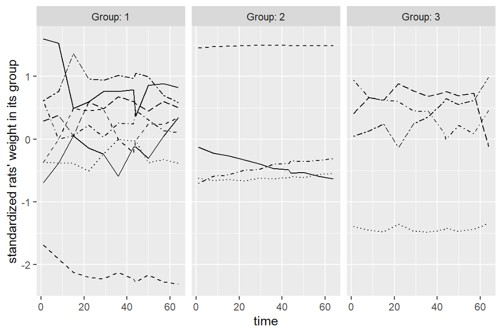

```r
ggplot(rats_long, aes(x= time, y = stdrats_G, linetype = ID)) + geom_line() + scale_linetype_manual(values = rep(1:10, times=4)) +
  facet_grid(. ~ Group, labeller = label_both) +
  theme(legend.position = "none") +
  scale_y_continuous(name = "standardized rats' weight in its group")
```

The figure above takes account the groups as well as the time. This means that the three plots aren’t directly comparable. Smaller changes inside the groups are now seen. They show similar patterns in group 2 and 3 as in the earlier plot. In Group 1 plot the small changes can be seen and one can conclude that the weights vary, but in the end are comparable. One outlier in the bottom of the plot.

### Standard error of mean plot

```r
rats_long_se <- rats_long %>% group_by(Group, time) %>%
  summarise( mean = mean(rats), se = sd(rats)/sqrt(length(rats))) %>% ungroup()
# Glimpse data
glimpse(rats_long_se)
```

```
## Rows: 33
## Columns: 4
## $ Group <fct> 1, 1, 1, 1, 1, 1, 1, 1, 1, 1, 1, 2, 2, 2, 2, 2, 2, 2, 2, 2, 2, 2…
## $ time  <int> 1, 8, 15, 22, 29, 36, 43, 44, 50, 57, 64, 1, 8, 15, 22, 29, 36, …
## $ mean  <dbl> 250.625, 255.000, 254.375, 261.875, 264.625, 265.000, 267.375, 2…
## $ se    <dbl> 5.381640, 4.629100, 4.057346, 4.808614, 3.909409, 4.166190, 3.87…
```

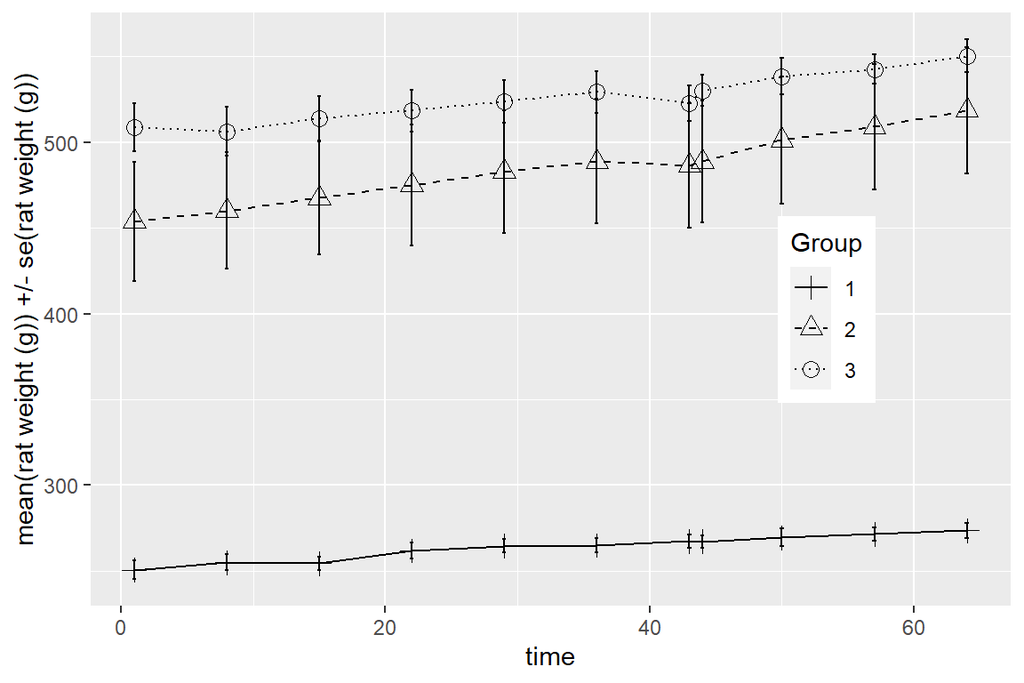

```r
ggplot(rats_long_se, aes(x = time, y = mean, linetype = Group, shape = Group)) +
  geom_line() +
  scale_linetype_manual(values = c(1,2,3)) +
  geom_point(size=3) +
  scale_shape_manual(values = c(3,2,1)) +
  geom_errorbar(aes(ymin=mean-se, ymax=mean+se, linetype="1"), width=0.3) +
  theme(legend.position = c(0.8,0.5)) +
  scale_y_continuous(name = "mean(rat weight (g)) +/- se(rat weight (g))")
```

In the figure above the mean weights in certain group and certain time step can be seen as well as error bars that are $2 \times se$, where $se$ is the standard error. Again, the upward trend can be seen in all of the groups, however, this is affect a lot by some high values especially in Group 2 (the heavy weight champion rat), thus large error bars in that group. Weight ranking between groups is the same here as seen in the first figure (Group 1 < Group 2 < Group 3).

### Outliers

```r
# Create a summary data by Group and ID with mean as the summary variable (ignoring baseline time = 1, not sure if that's needed here)
rats_long_delta <- rats_long %>%
  filter(time > 1) %>%
  group_by(Group, ID) %>%
  summarise( mean=mean(rats) ) %>%
  ungroup()
glimpse(rats_long_delta)
```

```
## Rows: 16
## Columns: 3
## $ Group <fct> 1, 1, 1, 1, 1, 1, 1, 1, 2, 2, 2, 2, 3, 3, 3, 3
## $ ID    <fct> 1, 2, 3, 4, 5, 6, 7, 8, 9, 10, 11, 12, 13, 14, 15, 16
## $ mean  <dbl> 263.2, 238.9, 261.7, 267.2, 270.9, 276.2, 274.6, 267.5, 443.9, 4…
```

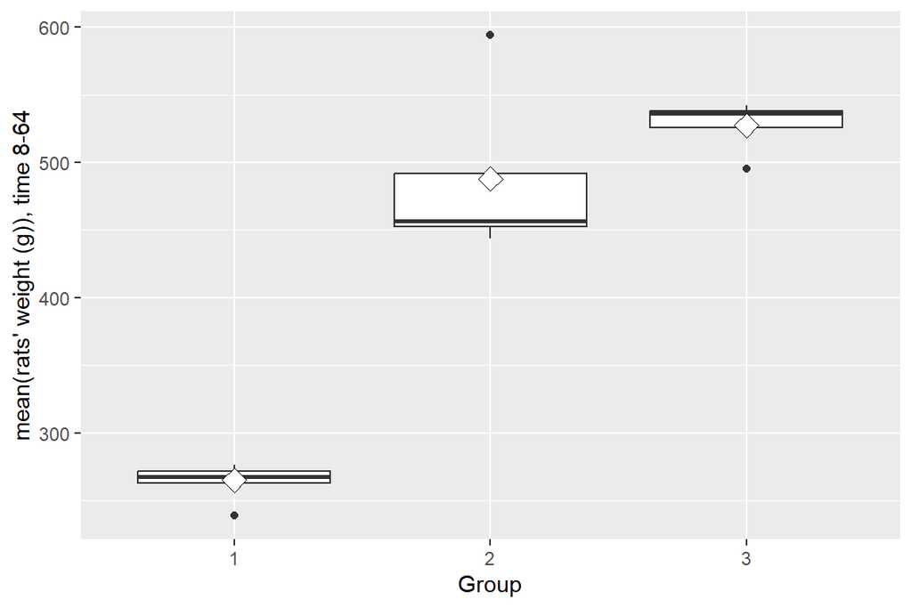

```r
# Draw a boxplot of the mean versus Group

ggplot(rats_long_delta, aes(x = Group, y = mean)) +
  geom_boxplot() +
  stat_summary(fun = "mean", geom = "point", shape=23, size=4, fill = "white") +
  scale_y_continuous(name = "mean(rats' weight (g)), time 8-64")
```

All Groups have one outlier: Group 1 low value, Group 2 (the heavy weight champion), Group 3 low value.

- Bold line is the mean or the diamond?
- Black dots as the outliers
- Box as the IQR (between 25th and 75 percentile)

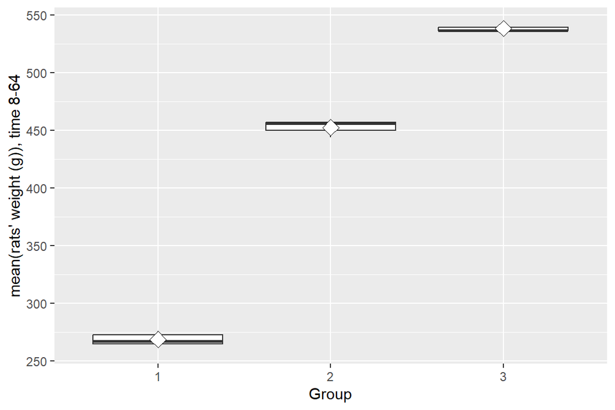

```r
# Filter out outliers IDs: 2, 12, 13

rats_long_filter <- rats_long_delta[!(rats_long_delta$ID == 2 | rats_long_delta$ID == 12 | rats_long_delta$ID == 13),]

# New plot
ggplot(rats_long_filter, aes(x = Group, y = mean)) +
  geom_boxplot() +
  stat_summary(fun = "mean", geom = "point", shape=23, size=4, fill = "white") +
  scale_y_continuous(name = "mean(rats' weight (g)), time 8-64")
```

Certainly there are no more outliers as they’ve been removed and the IQRs are narrower as well.

### Compare the mean of multiple groups using ANOVA

```r
# Load libraries
suppressWarnings({
library(tidyverse)
library(rstatix)
library(ggpubr)})
res.aov <- rats_long_filter %>% anova_test(mean ~ Group)
res.aov
```

```
## ANOVA Table (type II tests)
##
##   Effect DFn DFd        F        p p<.05   ges
## 1  Group   2  10 2836.445 1.69e-14     * 0.998
```

### Pairwise T-Test between Groups

```r
pwc <- rats_long_filter %>% pairwise_t_test(mean ~ Group, p.adjust.method="bonferroni")
pwc
```

```
## # A tibble: 3 × 9
##   .y.   group1 group2    n1    n2        p p.signif    p.adj p.adj.signif
## * <chr> <chr>  <chr>  <int> <int>    <dbl> <chr>       <dbl> <chr>
## 1 mean  1      2          7     3 3.99e-13 ****     1.20e-12 ****
## 2 mean  1      3          7     3 8.71e-15 ****     2.61e-14 ****
## 3 mean  2      3          3     3 3.86e- 9 ****     1.16e- 8 ****
```

According the pairwise T-test all Groups differ from each other statistically significantly. Let’s look this with a plot as well.

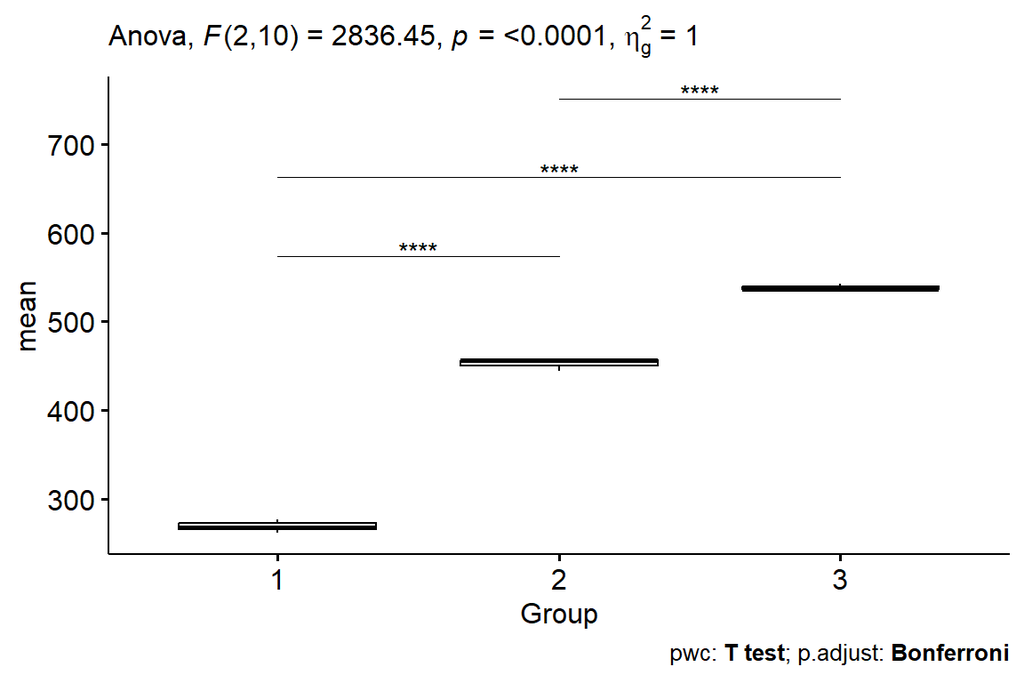

```r
pwc <- pwc %>% add_xy_position(x = "Group")
ggboxplot(rats_long_filter, x = "Group", y = "mean") +
  stat_pvalue_manual(pwc, label = "p.adj.signif", tip.length = 0, step.increase = 0.1) +
  labs(
    subtitle = get_test_label(res.aov, detailed = TRUE),
    caption = get_pwc_label(pwc)
  )
```

### Linear model

```r
# Making baseline rat weight (time = 1)
rats_long_filter2 <-  rats_long[!(rats_long$ID == 2 | rats_long$ID == 12 | rats_long$ID == 13),]
rats_long_filter2 <- rats_long_filter2 %>% filter(time<2)

# Making factorial into numeric value for linear model fit
rats_long_filter$Group_num <- as.numeric(rats_long_filter$Group)

# Fitting the linear model offset (maybe as constant) from the time = 1 rat weight
fit <- lm(I(mean - rats_long_filter2$rats) ~ 0 + Group_num, data = rats_long_filter)#, offset = rats_long_filter2$rats)


summary(fit)
```

```
##
## Call:
## lm(formula = I(mean - rats_long_filter2$rats) ~ 0 + Group_num,
##     data = rats_long_filter)
##
## Residuals:
##     Min      1Q  Median      3Q     Max
## -27.628  -6.828   6.224  12.824  33.148
##
## Coefficients:
##           Estimate Std. Error t value Pr(>|t|)
## Group_num    9.676      2.247   4.306  0.00102 **
## ---
## Signif. codes:  0 '***' 0.001 '**' 0.01 '*' 0.05 '.' 0.1 ' ' 1
##
## Residual standard error: 15.24 on 12 degrees of freedom
## Multiple R-squared:  0.6071, Adjusted R-squared:  0.5744
## F-statistic: 18.54 on 1 and 12 DF,  p-value: 0.001021
```

This model should have starting point of time = 1 (manual intercept) rat weights put into it and therefore the estimate (slope) of the linear model is only $9.7$. I haven’t been able to verify this using proper plot, since I don’t know how to plot that. Despite several attempts, all plots look kinda wrong. Well, too bad.

With just the current estimate the line won’t ever be inside the plot as seen bellow.

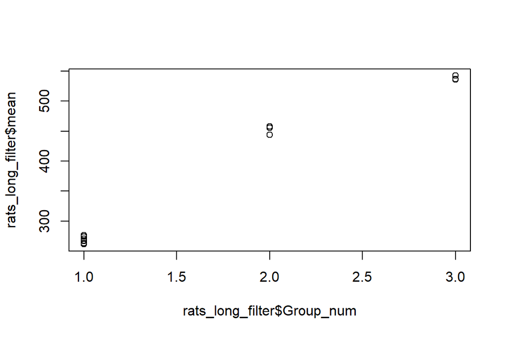

```r
plot(rats_long_filter$Group_num, rats_long_filter$mean)
abline(lm(I(mean - rats_long_filter2$rats) ~ 0 + Group_num, data = rats_long_filter))
```

Below a simple model without the forced intercept and data from time = 1.

```r
# A model without forced intercept
fit2 <- lm(mean ~ Group_num, data = rats_long_filter)
summary(fit2)
```

```
##
## Call:
## lm(formula = mean ~ Group_num, data = rats_long_filter)
##
## Residuals:
##     Min      1Q  Median      3Q     Max
## -20.078 -14.078  -8.976  -0.276  41.123
##
## Coefficients:
##             Estimate Std. Error t value Pr(>|t|)
## (Intercept)  136.575     14.326   9.533 1.19e-06 ***
## Group_num    139.901      7.616  18.369 1.33e-09 ***
## ---
## Signif. codes:  0 '***' 0.001 '**' 0.01 '*' 0.05 '.' 0.1 ' ' 1
##
## Residual standard error: 22.55 on 11 degrees of freedom
## Multiple R-squared:  0.9684, Adjusted R-squared:  0.9656
## F-statistic: 337.4 on 1 and 11 DF,  p-value: 1.328e-09
```

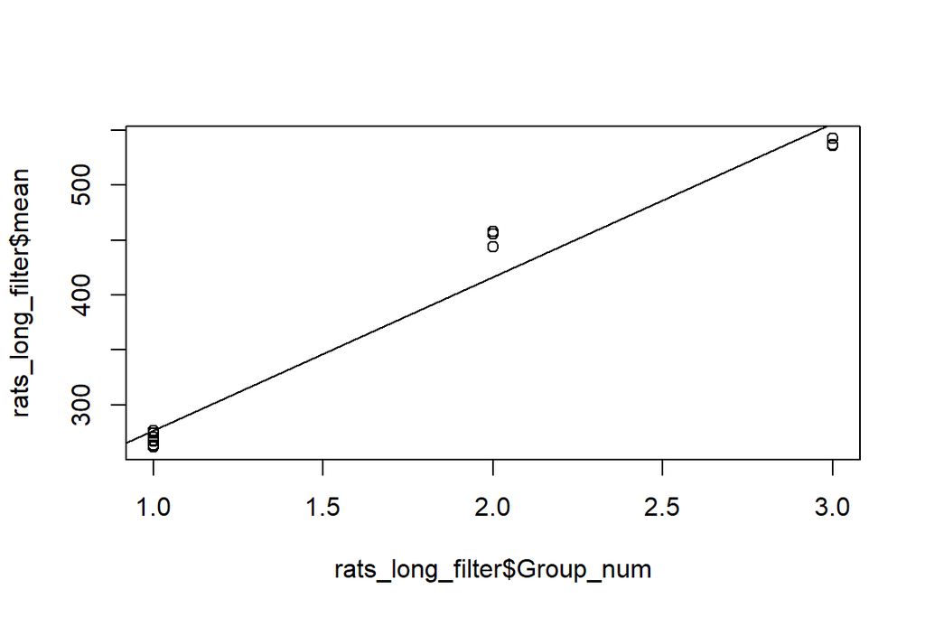

```r
plot(rats_long_filter$Group_num, rats_long_filter$mean)
abline(fit2)
```

I’ll fit models rat weight vs. time for every three groups in the next section. Probably wasn’t needed, however, I wasn’t sure what the whole linear model was getting at here.

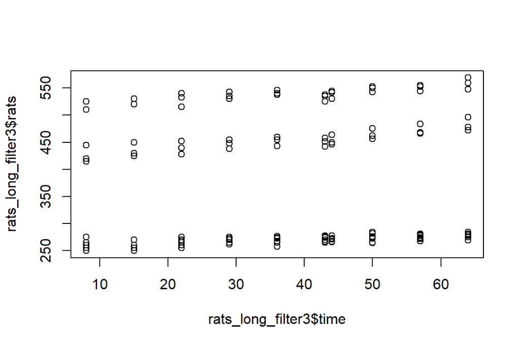

```r
suppressWarnings({
library(forestmangr)})
rats_long_filter3 <-  rats_long[!(rats_long$ID == 2 | rats_long$ID == 12 | rats_long$ID == 13),]
rats_long_filter_interc <- rats_long_filter3 %>% filter(time<2)
rats_long_filter3 <- rats_long_filter3 %>% filter(time>1)

fit3 <- lm_table(rats_long_filter3,rats ~ time, "Group")


plot(rats_long_filter3$time, rats_long_filter3$rats)
```

```r
fit3
```

```
##   Group       b0        b1      Rsqr  Rsqr_adj Std.Error
## 1     1 255.9465 0.3481166 0.5070623 0.4998133  6.029363
## 2     2 419.1086 0.9046571 0.7213175 0.7113646 10.077296
## 3     3 515.7123 0.6128903 0.6707895 0.6590319  7.694758
```

The table gives parameters for three linear models divided by Group.

- Group 2 has the highest value of $R^2 = 0.72$ meaning the best fit.
- Group 2 has also the highest slope $b_1$ representing the fastest grow rate

## 2. BPRS data

I have to say there is not much interpretation here as gave up the section since I never got the plots in the end to work.

### Plots

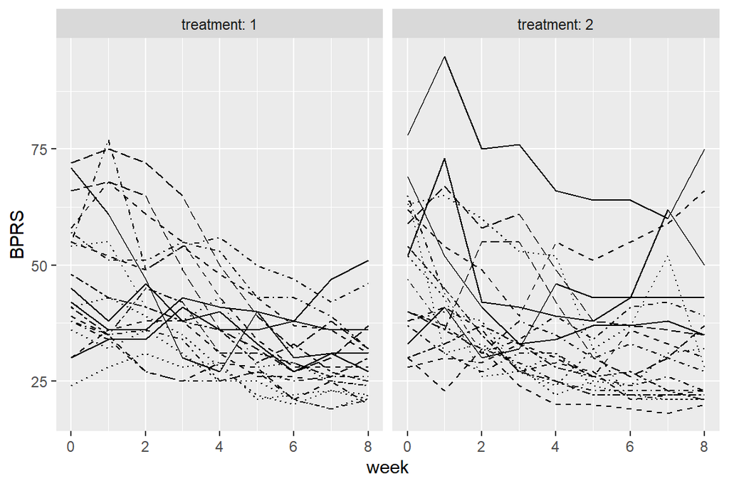

```r
# Week on x-axis and BPRS on y-axis rats body weight
ggplot(bprs_long, aes(x= week, y = bprs, linetype = subject)) + geom_line() + scale_linetype_manual(values = rep(1:10, times=4)) +
  facet_grid(. ~ treatment, labeller = label_both) +
  theme(legend.position = "none") +
  scale_y_continuous(limits = c(min(bprs_long$bprs), max(bprs_long$bprs)), name = "BPRS")
```

### Linear model

```r
bprs_long$treatment_num <- as.numeric(bprs_long$treatment)
BPRS_reg <- lm(bprs ~ week + treatment_num, data = bprs_long)
summary(BPRS_reg)
```

```
##
## Call:
## lm(formula = bprs ~ week + treatment_num, data = bprs_long)
##
## Residuals:
##     Min      1Q  Median      3Q     Max
## -22.454  -8.965  -3.196   7.002  50.244
##
## Coefficients:
##               Estimate Std. Error t value Pr(>|t|)
## (Intercept)    45.8817     2.2949  19.993   <2e-16 ***
## week           -2.2704     0.2524  -8.995   <2e-16 ***
## treatment_num   0.5722     1.3034   0.439    0.661
## ---
## Signif. codes:  0 '***' 0.001 '**' 0.01 '*' 0.05 '.' 0.1 ' ' 1
##
## Residual standard error: 12.37 on 357 degrees of freedom
## Multiple R-squared:  0.1851, Adjusted R-squared:  0.1806
## F-statistic: 40.55 on 2 and 357 DF,  p-value: < 2.2e-16
```

Looks like that the treatment is not statistically significant factor in this model, week and intercept are.

### Random Intercept Model

```r
suppressWarnings(library(lme4))
# Subject variable as the random effect
bprs_ref <- lmer(bprs ~ week + treatment_num + (1 | subject), data = bprs_long, REML = FALSE)
summary(bprs_ref)
```

```
## Linear mixed model fit by maximum likelihood  ['lmerMod']
## Formula: bprs ~ week + treatment_num + (1 | subject)
##    Data: bprs_long
##
##      AIC      BIC   logLik deviance df.resid
##   2748.7   2768.1  -1369.4   2738.7      355
##
## Scaled residuals:
##     Min      1Q  Median      3Q     Max
## -3.0481 -0.6749 -0.1361  0.4813  3.4855
##
## Random effects:
##  Groups   Name        Variance Std.Dev.
##  subject  (Intercept)  47.41    6.885
##  Residual             104.21   10.208
## Number of obs: 360, groups:  subject, 20
##
## Fixed effects:
##               Estimate Std. Error t value
## (Intercept)    45.8817     2.4413  18.794
## week           -2.2704     0.2084 -10.896
## treatment_num   0.5722     1.0761   0.532
##
## Correlation of Fixed Effects:
##             (Intr) week
## week        -0.341
## treatmnt_nm -0.661  0.000
```

### Random Intercept and Random Slope Model

```r
bprs_ref1 <- lmer(bprs ~ week + treatment_num + (week | subject), data = bprs_long, REML = FALSE)
summary(bprs_ref1)
```

```
## Linear mixed model fit by maximum likelihood  ['lmerMod']
## Formula: bprs ~ week + treatment_num + (week | subject)
##    Data: bprs_long
##
##      AIC      BIC   logLik deviance df.resid
##   2745.4   2772.6  -1365.7   2731.4      353
##
## Scaled residuals:
##     Min      1Q  Median      3Q     Max
## -2.8919 -0.6194 -0.0691  0.5531  3.7976
##
## Random effects:
##  Groups   Name        Variance Std.Dev. Corr
##  subject  (Intercept) 64.8222  8.0512
##           week         0.9609  0.9802   -0.51
##  Residual             97.4305  9.8707
## Number of obs: 360, groups:  subject, 20
##
## Fixed effects:
##               Estimate Std. Error t value
## (Intercept)    45.8817     2.5685  17.863
## week           -2.2704     0.2977  -7.626
## treatment_num   0.5722     1.0405   0.550
##
## Correlation of Fixed Effects:
##             (Intr) week
## week        -0.477
## treatmnt_nm -0.608  0.000
```

```r
anova(bprs_ref1, bprs_ref)
```

```
## Data: bprs_long
## Models:
## bprs_ref: bprs ~ week + treatment_num + (1 | subject)
## bprs_ref1: bprs ~ week + treatment_num + (week | subject)
##           npar    AIC    BIC  logLik deviance  Chisq Df Pr(>Chisq)
## bprs_ref     5 2748.7 2768.1 -1369.4   2738.7
## bprs_ref1    7 2745.4 2772.6 -1365.7   2731.4 7.2721  2    0.02636 *
## ---
## Signif. codes:  0 '***' 0.001 '**' 0.01 '*' 0.05 '.' 0.1 ' ' 1
```

Looks like that there is a statistically significant difference $p = 0.026$ between models **ref** and **ref1**.

### Random Intercept and Random Slope Model with interaction

```r
bprs_ref2 <- lmer(bprs ~ week * treatment_num + (week | subject), data = bprs_long, REML = FALSE)
summary(bprs_ref2)
```

```
## Linear mixed model fit by maximum likelihood  ['lmerMod']
## Formula: bprs ~ week * treatment_num + (week | subject)
##    Data: bprs_long
##
##      AIC      BIC   logLik deviance df.resid
##   2744.3   2775.4  -1364.1   2728.3      352
##
## Scaled residuals:
##     Min      1Q  Median      3Q     Max
## -3.0513 -0.6271 -0.0768  0.5288  3.9260
##
## Random effects:
##  Groups   Name        Variance Std.Dev. Corr
##  subject  (Intercept) 65.0049  8.0626
##           week         0.9687  0.9842   -0.51
##  Residual             96.4702  9.8219
## Number of obs: 360, groups:  subject, 20
##
## Fixed effects:
##                    Estimate Std. Error t value
## (Intercept)         50.1767     3.5159  14.271
## week                -3.3442     0.6711  -4.983
## treatment_num       -2.2911     1.9090  -1.200
## week:treatment_num   0.7158     0.4010   1.785
##
## Correlation of Fixed Effects:
##             (Intr) week   trtmn_
## week        -0.768
## treatmnt_nm -0.814  0.753
## wk:trtmnt_n  0.684 -0.896 -0.840
```

```r
anova(bprs_ref2, bprs_ref1)
```

```
## Data: bprs_long
## Models:
## bprs_ref1: bprs ~ week + treatment_num + (week | subject)
## bprs_ref2: bprs ~ week * treatment_num + (week | subject)
##           npar    AIC    BIC  logLik deviance  Chisq Df Pr(>Chisq)
## bprs_ref1    7 2745.4 2772.6 -1365.7   2731.4
## bprs_ref2    8 2744.3 2775.4 -1364.1   2728.3 3.1712  1    0.07495 .
## ---
## Signif. codes:  0 '***' 0.001 '**' 0.01 '*' 0.05 '.' 0.1 ' ' 1
```

As far as I can see there is no statistically significant difference between models **ref1** and **ref2**. Then again, model **ref2** might be constructed wrong.

### Plots

Plot of the observation and calculating the prediction for models **Random Intercept Model** and **Random Intercept and Random Slope Model** as their results were statistical significantly different from each other, whereas the **Random Intercept and Random Slope Model** and the **Random Intercept and Random Slope Model with interaction** did not differ statistically.

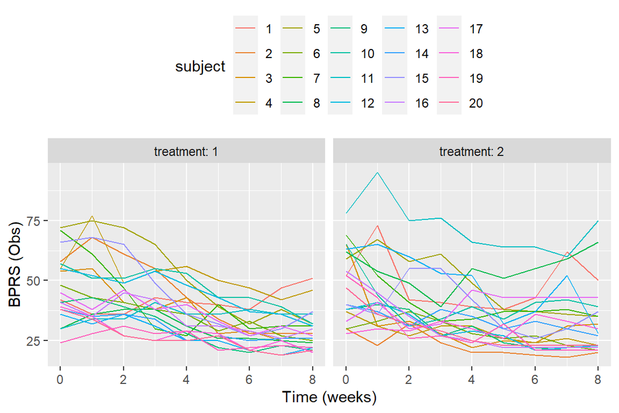

```r
# Never got this one to work...oh well

#ggplot(bprs_long, aes(x = week, y = bprs, group = subject, color = treatment)) +
#  geom_point() +
#  geom_line(aes(linetype = factor(treatment))) +
#  scale_linetype_manual(values = c("solid", "dotdash")) +
#  scale_x_continuous(name = "Weeks") +
#  scale_y_continuous(name = "BPRS") +
#  theme(legend.position = "top")


# Observations
ggplot(bprs_long, aes(x = week, y = bprs, color = subject)) +
  geom_line() +
  facet_grid(~treatment,labeller = label_both)+
  scale_x_continuous(name = "Time (weeks)", breaks = seq(0, 8, 2)) +
  scale_y_continuous(name = "BPRS (Obs)") +
  theme(legend.position = "top")
```

```r
# Calculating predicitions
bprs_long$ref1 <- predict(object=bprs_ref1)

bprs_long$ref <- predict(object=bprs_ref)
```

### Random Intercept Model Plot

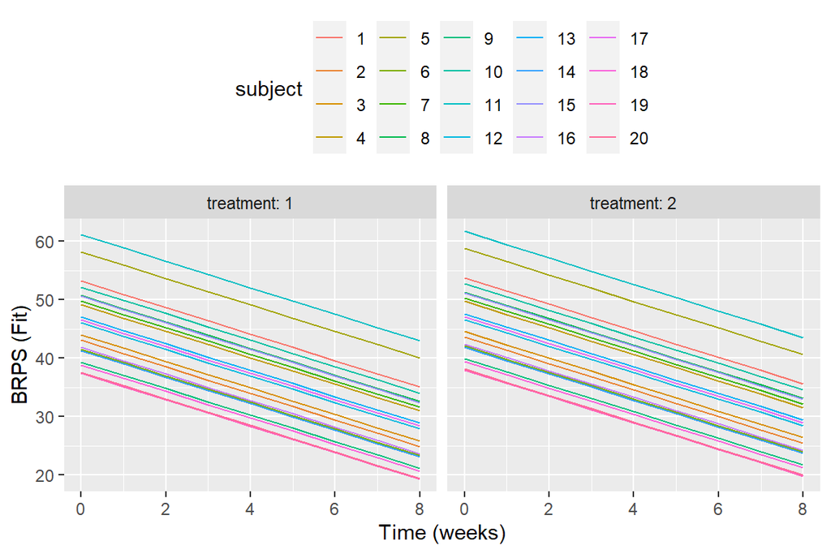

```r
# Model ref plot
ggplot(bprs_long, aes(x = week, y = ref, color = subject)) +
  geom_line() +
  facet_grid(~treatment,labeller = label_both)+
  scale_x_continuous(name = "Time (weeks)", breaks = seq(0, 8, 2)) +
  scale_y_continuous(name = "BRPS (Fit)") +
  theme(legend.position = "top")
```

All of the models have the same slope, but the intercept ($y(x=0)$) is different.

### Random Intercept and Random Slope Model Plot

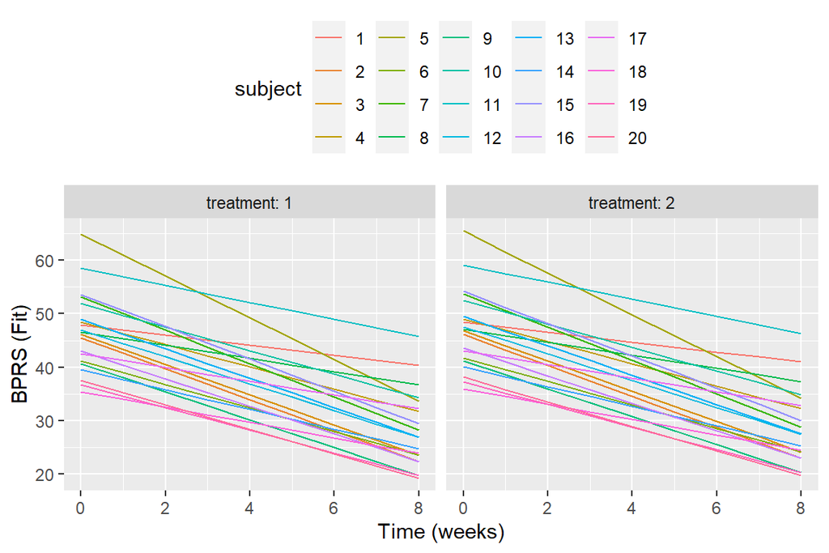

```r
# Model ref1 plot
ggplot(bprs_long, aes(x = week, y = ref1, color = subject)) +
  geom_line() +
  facet_grid(~treatment,labeller = label_both)+
  scale_x_continuous(name = "Time (weeks)", breaks = seq(0, 8, 2)) +
  scale_y_continuous(name = "BPRS (Fit)") +
  theme(legend.position = "top")
```

Here the slopes differ from each other as well as the intercepts. I’d reckon that the latter model should model the data better based on these plots, however, difficult to say how good it would be for actual prediction.